# TU060 - Math 9102 – PSI - Portfolio

Joseph O’Carroll

08/11/2020

```r
# ********************************************************************
#
#   Setup Section
#
# ********************************************************************
needed_packages <- c("tidyverse", "readxl", "lubridate", "jsonlite", "ggplot2", "gtools", "httr", "readr", "psych", "kableExtra")
# Extract not installed packages
not_installed   <- needed_packages[!(needed_packages %in% installed.packages()[, "Package"])]
# Install not installed packages
if (length(not_installed)) {
  install.packages(not_installed)
}
library(tidyverse)
library(readxl)
library(ggplot2)
library(data.table)
library(knitr)
library(kableExtra)
library(psych) ## added for quick stat descriptions
```

# Import dataset

```r
############
# PART: Import data
############
# Dateset 1 : Import sperformance-dataset  ---------------------------
tbl_sperf_all <- read.csv('sperformance-dataset.csv', header = TRUE)
names(tbl_sperf_all)[1]   <- 'School' # Fix issue with the name of first field.

# Dateset 2 : Import sperformance-dataset variable description ---------------------------
tbl_sperf_description_all <- read.csv('TU060_MATH9102_Student_variables_description.csv', header = TRUE)
```

# Describe the sample

*As part of our analysis we need to describe our sample and our populations. We start by informing our consumer/user of the variables of interest that we have identified and what concepts they represent in our conceptual framework. Different statistical tests will be applicable for different statistical data types. We provide measures of the different statistical data types in sufficient detail for our consumers to be able to understand what we have done and why we have done it without the need to access the sample data themselves. We describe the sample by providing summary statistics about the variables of interest in our sample. Later on we can use inferential statistical methods to infer population parameters from sample statistics.*

The sample dataset contains 382 records and 33 variables of interest. The sample was constructed from a combination of school records and a closed questionnaire answered by students to collect demographic data. The variables are described in the table below, where the last four rows denote the variables taken from the school reports.

```r
############
# PART: Describe the sample
############
# https://cran.r-project.org/web/packages/kableExtra/vignettes/awesome_table_in_html.html
list_variables_names <- names(tbl_sperf_all)
tbl_sperf_description_all %>% kbl(caption = "Statistical Data Types")%>%
  kable_styling(bootstrap_options = c("striped", "hover"))
```

Statistical Data Types

[output not shown]

## Numerical Data:

*For numerical data the measurements we need to describe are the center point of the data and the spread of the data. This tells us the overall shape/distribution of the data for the variable of interest. The shape of the data is important because it helps us during hypothesis testing to determine what sort of tests we can use, for instance if we can use the parametric tests, or if we have to revert to the less statistically powerful non-parametric tests.*

*We also must explain any unusual aspects of our data, such as outliers, because these are definitely impacting the shape of our data, or central tendency, and our spread. We may also have gaps in our data which need to be explained. Similarly any clusters of data need to be explained.*

In the sample dataset there are 3 numerical variables of interest, related to student performance. These are absences, grades in maths and grades in Portugese. The table below contains statistics that describe the center point (Mean and Median), the spread (Range, IQR, min and max) for each variable and the variability (Standard Deviation, Median absolute Deviation). These statistics inform us about the overall shape an distribution of the variables under consideration. The shape of the distribution is important because it will help us during hypothesis testing to determine what sort of tests we can use, for instance if we can use parametric tests or if we have to revert to the less statistically powerful non-parameteric tests.

```r
############
# PART: Describe the numberical variables
############
tbl_sperf_numerical_stats <- tbl_sperf_all %>%
  select(age,
         absences.m,
         absences.p,
         contains('mG'),
         contains('pG')
  ) %>%
  psych::describe(omit = TRUE, IQR = TRUE)

tbl_sperf_numerical_stats %>%
  kbl(caption = "Statistical Data Types") %>%
  kable_styling(bootstrap_options = c("striped", "hover"))
```

Statistical Data Types

|  | vars | n | mean | sd | median | trimmed | mad | min | max | range | skew | kurtosis | se | IQR |
| --- | --- | --- | --- | --- | --- | --- | --- | --- | --- | --- | --- | --- | --- | --- |
| age | 1 | 382 | 16.586387 | 1.173470 | 17.0 | 16.552288 | 1.4826 | 15 | 22 | 7 | 0.3953408 | 0.0648447 | 0.0600400 | 1.00 |
| absences.m | 2 | 382 | 5.319372 | 7.625251 | 3.0 | 3.931373 | 4.4478 | 0 | 75 | 75 | 4.0116261 | 26.2928570 | 0.3901418 | 8.00 |
| absences.p | 3 | 382 | 3.672775 | 4.905965 | 2.0 | 2.666667 | 2.9652 | 0 | 32 | 32 | 2.1655187 | 6.1782596 | 0.2510110 | 6.00 |
| mG1 | 4 | 382 | 10.861256 | 3.349167 | 10.5 | 10.745098 | 3.7065 | 3 | 19 | 16 | 0.2741912 | -0.7061137 | 0.1713583 | 5.00 |
| mG2 | 5 | 382 | 10.712042 | 3.832560 | 11.0 | 10.830065 | 2.9652 | 0 | 19 | 19 | -0.3970490 | 0.4666241 | 0.1960908 | 4.75 |
| mG3 | 6 | 382 | 10.387435 | 4.687242 | 11.0 | 10.813726 | 4.4478 | 0 | 20 | 20 | -0.7003219 | 0.2415275 | 0.2398202 | 6.00 |
| pG1 | 7 | 382 | 12.112565 | 2.556531 | 12.0 | 12.091503 | 2.9652 | 0 | 19 | 19 | -0.1523548 | 0.6986985 | 0.1308035 | 4.00 |
| pG2 | 8 | 382 | 12.238220 | 2.468341 | 12.0 | 12.153595 | 2.9652 | 5 | 19 | 14 | 0.2368869 | -0.2038155 | 0.1262913 | 3.00 |
| pG3 | 9 | 382 | 12.515707 | 2.945438 | 13.0 | 12.620915 | 2.9652 | 0 | 19 | 19 | -0.9891237 | 3.3902597 | 0.1507017 | 3.00 |

```r
NA
```

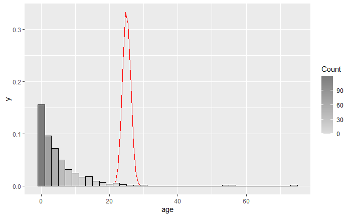

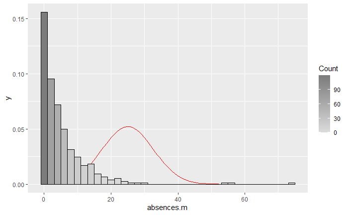

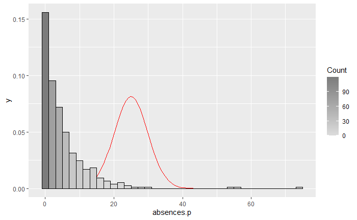

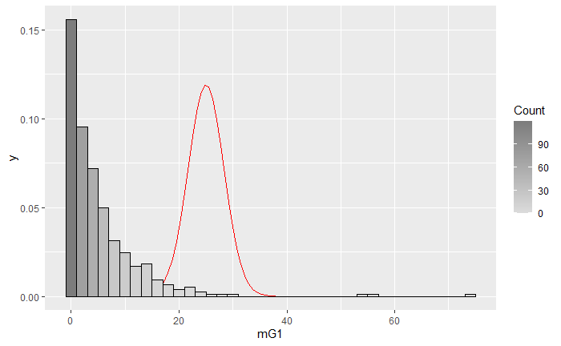

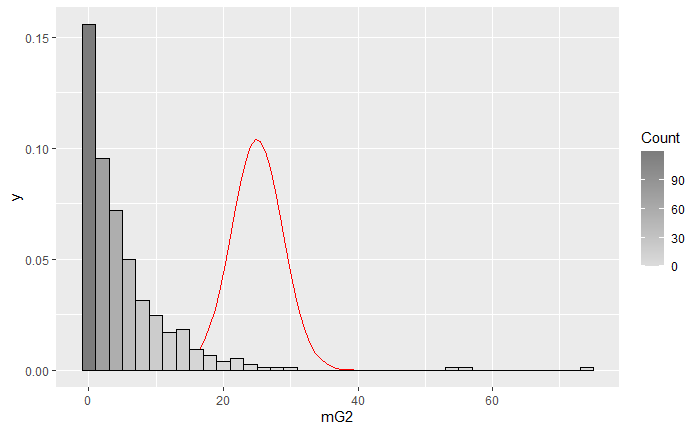

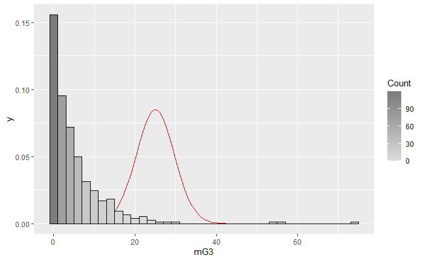

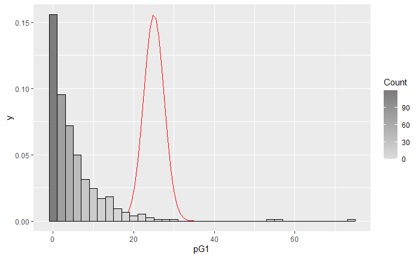

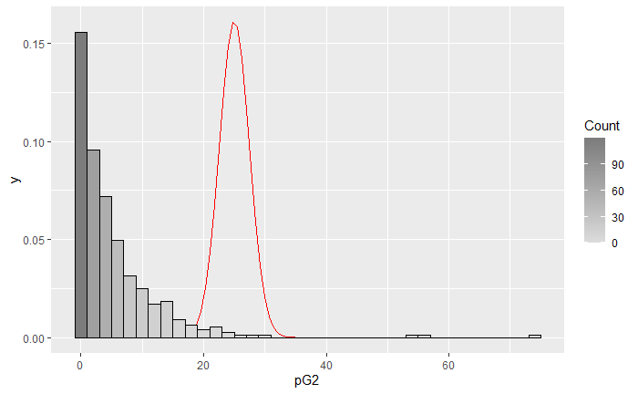

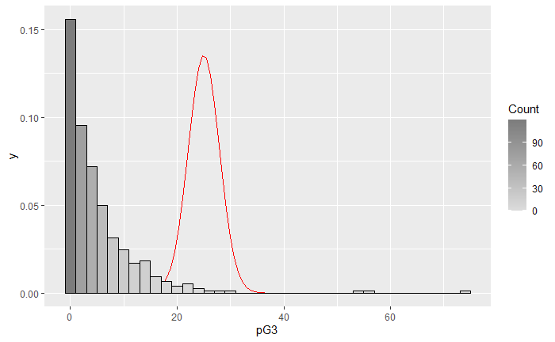

```r
############
# PART: Visualise the numberical variables
############
tbl_sperf_numerical_subset <- tbl_sperf_all %>%
  select(age,
         absences.m,
         absences.p,
         contains('mG'),
         contains('pG')
  )

#Create histogram
num_diagram_count <- nrow(tbl_sperf_numerical_stats)
for(n in 1:num_diagram_count) {
  gs <- tbl_sperf_numerical_subset %>%
    ggplot(aes(x = absences.m))+
    stat_function(fun   = dnorm,
                           color = "red",
                           args  = list(mean = 25,
                           sd    = tbl_sperf_numerical_stats[n,]$sd),
                           na.rm = TRUE)
  gs <- gs + labs(x = names(tbl_sperf_numerical_subset)[n])
  gs <- gs + geom_histogram(binwidth = 2, colour = "black", aes(y = ..density.., fill = ..count..))
  gs <- gs + scale_fill_gradient("Count", low = "#DCDCDC", high = "#7C7C7C")
  show(gs)
}
```